# Danny Pan- HW3

```r
library(tidyverse)
library(MatchIt)
df_read <- read_csv("pm25_data.csv")
```

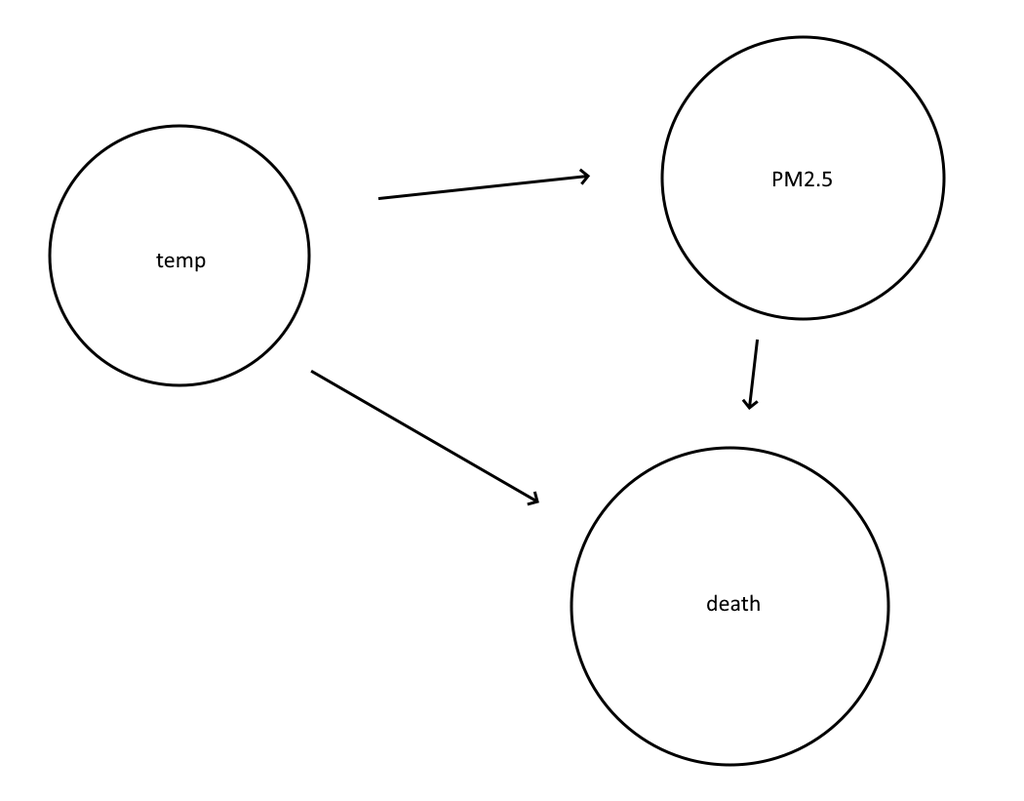

```r
df <- df_read %>% drop_na() %>% mutate(above = as.integer(above == "above"))

ps_model <- matchit(above ~ temp,
                    data = df,
                    method = "nearest",
                    distance = "glm",
                    replace = TRUE)

print(ps_model)
```

```
## A `matchit` object
##  - method: 1:1 nearest neighbor matching with replacement
##  - distance: Propensity score
##              - estimated with logistic regression
##  - number of obs.: 2305 (original), 149 (matched)
##  - target estimand: ATT
##  - covariates: temp
```

```r
summary(ps_model)
```

```
##
## Call:
## matchit(formula = above ~ temp, data = df, method = "nearest",
##     distance = "glm", replace = TRUE)
##
## Summary of Balance for All Data:
##          Means Treated Means Control Std. Mean Diff. Var. Ratio eCDF Mean
## distance        0.0617        0.0329          0.7464     2.3950    0.1682
## temp           67.7350       55.1391          0.6743     1.2398    0.1682
##          eCDF Max
## distance   0.4108
## temp       0.4108
##
## Summary of Balance for Matched Data:
##          Means Treated Means Control Std. Mean Diff. Var. Ratio eCDF Mean
## distance        0.0617        0.0619         -0.0039     0.9833    0.0002
## temp           67.7350       67.7607         -0.0014     0.9941    0.0002
##          eCDF Max Std. Pair Dist.
## distance   0.0256          0.0039
## temp       0.0256          0.0014
##
## Sample Sizes:
##               Control Treated
## All           2227.        78
## Matched (ESS)   64.72      78
## Matched         71.        78
## Unmatched     2156.         0
## Discarded        0.         0
```

3.

```r
matched_data <- match.data(ps_model)

lin <- lm(death ~ above, data = matched_data, weights = weights)
summary(lin)
```

```
##
## Call:
## lm(formula = death ~ above, data = matched_data, weights = weights)
##
## Weighted Residuals:
##     Min      1Q  Median      3Q     Max
## -55.846 -12.321  -1.321   9.736  73.679
##
## Coefficients:
##             Estimate Std. Error t value Pr(>|t|)
## (Intercept) 163.7949     2.3662  69.222   <2e-16 ***
## above         0.5256     3.2704   0.161    0.873
## ---
## Signif. codes:  0 '***' 0.001 '**' 0.01 '*' 0.05 '.' 0.1 ' ' 1
##
## Residual standard error: 19.94 on 147 degrees of freedom
## Multiple R-squared:  0.0001757,  Adjusted R-squared:  -0.006626
## F-statistic: 0.02583 on 1 and 147 DF,  p-value: 0.8725
```

4.

Decisions changed:

1- Match on days where PM2.5 levels are below 35 instead of days where PM2.5 levels were above 35.

2- Fit a regression model on the PM2.5 level rather than the indicator function of whether PM2.5 was above 35.

```r
df2 <- df_read %>% drop_na() %>% mutate(above = as.integer(above == "below"))

ps_model2 <- matchit(above ~ temp,
                    data = df2,
                    method = "nearest",
                    distance = "glm",
                    replace = TRUE)

print(ps_model2)
```

```
## A `matchit` object
##  - method: 1:1 nearest neighbor matching with replacement
##  - distance: Propensity score
##              - estimated with logistic regression
##  - number of obs.: 2305 (original), 2300 (matched)
##  - target estimand: ATT
##  - covariates: temp
```

```r
summary(ps_model2)
```

```
##
## Call:
## matchit(formula = above ~ temp, data = df2, method = "nearest",
##     distance = "glm", replace = TRUE)
##
## Summary of Balance for All Data:
##          Means Treated Means Control Std. Mean Diff. Var. Ratio eCDF Mean
## distance        0.9671        0.9383          1.1551     0.4175    0.1682
## temp           55.1391       67.7350         -0.7508     0.8066    0.1682
##          eCDF Max
## distance   0.4108
## temp       0.4108
##
## Summary of Balance for Matched Data:
##          Means Treated Means Control Std. Mean Diff. Var. Ratio eCDF Mean
## distance        0.9671        0.9671          0.0018     0.9769    0.0122
## temp           55.1391       55.4685         -0.0196     1.0477    0.0122
##          eCDF Max Std. Pair Dist.
## distance    0.066          0.0381
## temp        0.066          0.0564
##
## Sample Sizes:
##               Control Treated
## All             78.      2227
## Matched (ESS)   27.82    2227
## Matched         73.      2227
## Unmatched        5.         0
## Discarded        0.         0
```

```r
matched_data2 <- match.data(ps_model2)

lin2 <- lm(death ~ above, data = matched_data2, weights = weights)
summary(lin2)
```

```
##
## Call:
## lm(formula = death ~ above, data = matched_data2, weights = weights)
##
## Weighted Residuals:
##     Min      1Q  Median      3Q     Max
## -53.489 -13.818  -1.818  11.182 117.378
##
## Coefficients:
##             Estimate Std. Error t value Pr(>|t|)
## (Intercept)  171.832      2.332  73.695  < 2e-16 ***
## above         -9.013      2.370  -3.804 0.000146 ***
## ---
## Signif. codes:  0 '***' 0.001 '**' 0.01 '*' 0.05 '.' 0.1 ' ' 1
##
## Residual standard error: 19.92 on 2298 degrees of freedom
## Multiple R-squared:  0.006257,   Adjusted R-squared:  0.005825
## F-statistic: 14.47 on 1 and 2298 DF,  p-value: 0.0001462
```

```r
############
lin3 <- lm(death ~ pm25, data = matched_data, weights = weights)
summary(lin3)
```

```
##
## Call:
## lm(formula = death ~ pm25, data = matched_data, weights = weights)
##
## Weighted Residuals:
##    Min     1Q Median     3Q    Max
## -55.48 -12.33  -0.83  10.64  73.29
##
## Coefficients:
##              Estimate Std. Error t value Pr(>|t|)
## (Intercept) 162.42265    4.00462   40.56   <2e-16 ***
## pm25          0.05385    0.11954    0.45    0.653
## ---
## Signif. codes:  0 '***' 0.001 '**' 0.01 '*' 0.05 '.' 0.1 ' ' 1
##
## Residual standard error: 19.93 on 147 degrees of freedom
## Multiple R-squared:  0.001379,   Adjusted R-squared:  -0.005415
## F-statistic: 0.2029 on 1 and 147 DF,  p-value: 0.653
```

1.

Controlling for temperature, the causal effect of having PM2.5 levels above the 35 𝜇g/m3 standard is about 0.5256 more deaths per day. The p value of 0.873 suggests that there is no significant difference in deaths for days with higher PM2.5 levels. There is no significant evidence that PM2.5 levels above the 35 𝜇g/m3 standard causes excess daily mortality in New York City.

2.